# Assignment 4

Bayesian Statistics

Daniel Carpenter

April 2022

All questions and parts done completely.

# 1 Task 1 - GLM

## 1.1 Overview of Problem

### 1.1.1 Soft Drink Delivery Times Problem

- Goal: estimation of the required time needed by each employee to refill an automatic vending machines owned and served by the company.
- For this reason, a small quality assurance study was set-up by an industrial engineer of the company.
  - As the response variable he considered the `total service time` (measured in minutes) of each machine, including its stocking with beverage products and any required maintenance or housekeeping.
  - After examining the problem, the industrial engineer recommended two important variables which affect delivery time:
1. the `number of cases of stocked products` and
2. the `distance walked by the employee` (measured in feet).

A dataset of *25 observations* was collected.

## 1.2 `a` Mathematics

- The *linear predictor* of this data are the `cases` and `distance` variables
- Since the *predicted variable* `time` is interval data, therefore:
  - The *link* function will be linear $\mu = lin(x)$
  - the *Metric* scale will be used.
  - Since the Metric scale is used, a typical *noise distribution* for Metric scale types of predicted variables is normally distributed, or $y$ ~ $N(\mu, \sigma)$

### 1.2.1 JAGS Model

```r
# The JAGS Model
modelString =
  "
  model {

    # model’s likelihood
    for (i in 1:n) {
      time[i] ~ dnorm( mu[i], tau ) # stochastic componenent
      mu[i] <- beta0 + (beta1 * cases[i]) + (beta2 * distance[i])
    }

    # prior distributions
    beta0 ~ dnorm(  0.0, 1.0E-4)
    beta1 ~ dnorm(  0.0, 1.0E-4)
    beta2 ~ dnorm(  0.0, 1.0E-4)
    tau   ~ dgamma( 0.01, 0.01 )
  }
  "
```

## 1.3 `b` Distribution of Data

### 1.3.1 Data for Model

```r
# Data from soft drink experiment. See details below
dataList  =
  list(n = 25,

       # Total Service time (predicted variable)
       # Measure: minutes
       time = c(16.68, 11.5, 12.03, 14.88,
                13.75, 18.11, 8, 17.83, 79.24,
                21.5, 40.33, 21, 13.5, 19.75,
                24, 29, 15.35, 19, 9.5, 35.1,
                17.9, 52.32, 18.75, 19.83, 10.75),

       # Distance an employee walks on foot to the vending machine
       # (predictor variable 1)
       # Measure: feet
       distance = c(560, 220, 340, 80, 150, 330,
                    110, 210, 1460, 605, 688, 215,
                    255, 462, 448, 776, 200, 132,
                    36, 770, 140, 810, 450, 635, 150),

       # Number of cases of stocked products to restock
       # (predictor variable 2)
       # Measure: Number of cases of product
       cases = c( 7, 3, 3, 4, 6,
                  7, 2, 7, 30, 5,
                  16, 10, 4, 6, 9,
                  10, 6, 7, 3, 17,
                  10, 26, 9, 8, 4)
       )
```

### 1.3.2 Examine the Data

```r
library(tidyverse)
library(ggplot2)

# Boxplots of the data
df.softDrinks <- data.frame(dataList$time, dataList$distance, dataList$cases)
colnames(df.softDrinks) <- c('time', 'distance', 'cases')
df.softDrinks <- df.softDrinks%>%
  pivot_longer(cols      = everything(),
               names_to  = 'name',
               values_to = 'value')

# Show some of the pivoted Dataset
head(df.softDrinks)
```

```
## # A tibble: 6 x 2
##   name     value
##   <chr>    <dbl>
## 1 time      16.7
## 2 distance 560
## 3 cases      7
## 4 time      11.5
## 5 distance 220
## 6 cases      3
```

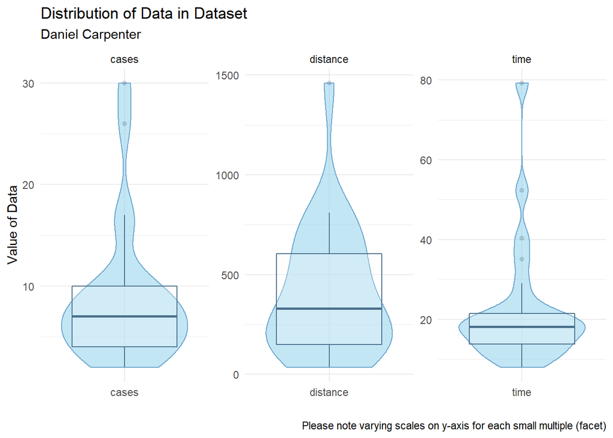

```r
# Create the distribution of data plot
df.softDrinks %>%
  ggplot(aes(x     = name,
             y     = value)) +
  theme_minimal() +

  # Create a violin plot under the boxplot to view tails
  geom_violin(color = 'skyblue3',
               fill  = 'skyblue',
               alpha = 0.5) +

  # Create the box plot
  geom_boxplot(color = 'skyblue4',
               fill  = 'grey99',
               alpha = 0.25) +

  # Wrap each variable on the columns
  facet_wrap(~name,
             ncol=3,
             scales = 'free') +
  labs(title = 'Distribution of Data in Dataset',
       subtitle = 'Daniel Carpenter',
       x = '',
       y = 'Value of Data',
       caption = 'Please note varying scales on y-axis for each small multiple (facet)')
```

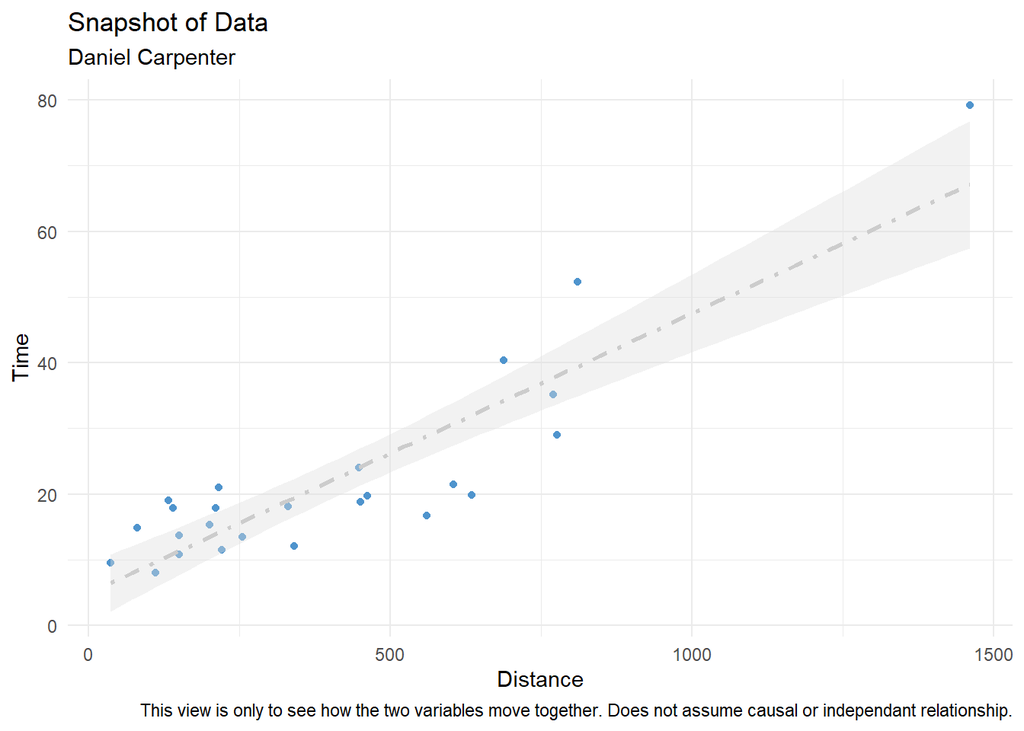

```r
# Scatter of the data
# Function to see data: how does prediced value compare to the predictor?
getGLMPlot <- function(predictedValue, predictor, methodName = 'glm', ...)
{
  df <- data.frame(predictedValue, predictor)
  colnames(df) <- c('predictedValue', 'predictor')

  plot.glm <- df %>%
    ggplot(aes(y = predictedValue,
               x = predictor)) +
    labs(title    = 'Snapshot of Data',
         subtitle = 'Daniel Carpenter',
         caption = 'This view is only to see how the two variables move together. Does not assume causal or independant relationship.',
         ...) +
    theme_minimal() +

    # Points
    geom_point(color = 'steelblue3') +

    # Using a GLM smoother
    geom_smooth(method = methodName,
                color = 'grey80',
                linetype = 'dotdash',
                fill = 'grey87')

  # print(plot.glm)
  return(plot.glm)
}

# Distance as a predictor
getGLMPlot(predictedValue = dataList$time    , y = 'Time',
           predictor      = dataList$distance, x = 'Distance')
```

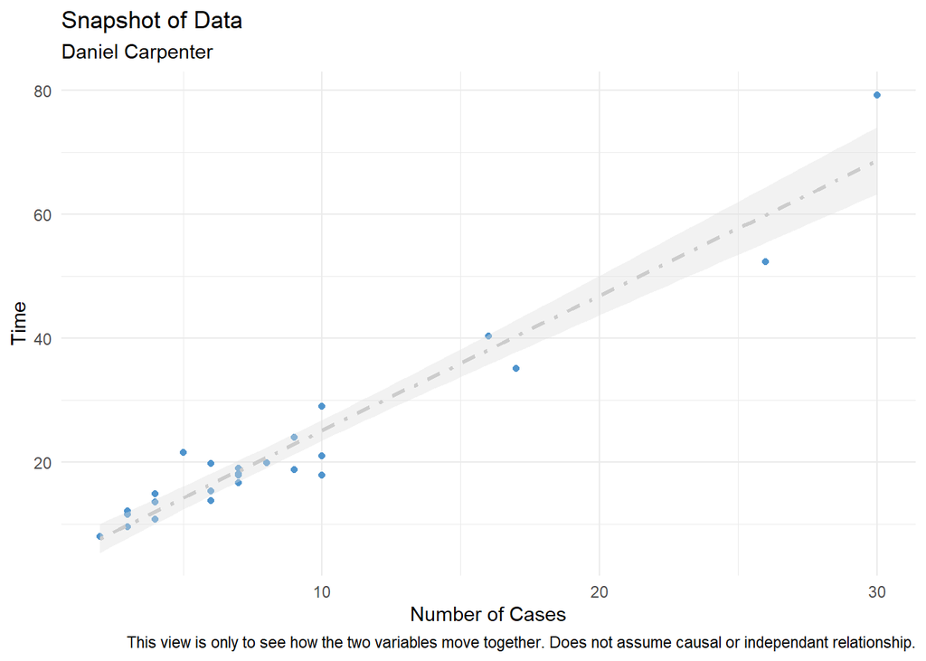

```r
# Num. Cases as a predictor
getGLMPlot(predictedValue = dataList$time, y = 'Time',
           predictor      = dataList$cases, x = 'Number of Cases')
```

### 1.3.3 MCMC Model Control Inputs

```r
# Model Name and Root
fileNameRoot= "Task 1 JAGS Output (Soft Drinks)/" # Directory
modelName   = 'SoftDrinks'      # Name of the model for File Naming


## MCMC Controls
adaptSteps  = 500               # Number of steps to adapt the samplers
burnInSteps = 1000              # Number of steps to burn-in the chains
nChains     = 3                 # nChains should be 2 or more for diagnostics
nIter       = 10000             # Total Number of iterations to perform


## Parameter Definitions
parameters  = c("tau",          # The parameters to be monitored
                "beta0",
                "beta1",
                'beta2')
```

## 1.4 `c-g`

### 1.4.1 Function to Run the JAGS Model

```r
runJagsFunction <- function(modelString, parameters, nIter=10000, # Total iterations
                            initsList   = list( tau   = 1,  # Initial parameter values
                                                beta0 = 1,
                                                beta1 = 0,
                                                beta2 = 0 )) {

  source("DBDA2E-utilities.R") # Must be in R's current working directory.
  library(rjags)

  # Create the directory for the JAGS output
  dir.create(fileNameRoot)

  # Create a text file to hold the model string
  writeLines( modelString , con=paste0(modelName, ".txt") )

  # Run the Chains:
  jagsModel = jags.model(file     = paste0(modelName, ".txt"),
                         data     = dataList,
                         inits    = initsList,
                         n.chains = nChains,
                         n.adapt  = adaptSteps
                         )

  # Burn-in:
  cat( "Burning in the MCMC chain...\n" )
  update( jagsModel , n.iter=burnInSteps )

  # Sample MCMC
  cat( "Sampling final MCMC chain...\n" )
  codaSamples = coda.samples( jagsModel, variable.names=parameters, n.iter=nIter )

  # Note the resulting codaSamples object has these indices:
  #   codaSamples[[ chainIdx ]][ stepIdx , paramIdx ]

  # Save the coda samples
  save( codaSamples , file=paste0(fileNameRoot,"Mcmc.Rdata") )

  return(codaSamples)
}
```

### 1.4.2 Run Jags Model

```r
# Run the fun and store
codaSamples <- runJagsFunction(modelString, parameters)
```

```
##
## Kruschke, J. K. (2015). Doing Bayesian Data Analysis, Second Edition:
## A Tutorial with R, JAGS, and Stan. Academic Press / Elsevier.
##
##
##
## Burning in the MCMC chain...
## Sampling final MCMC chain...
```

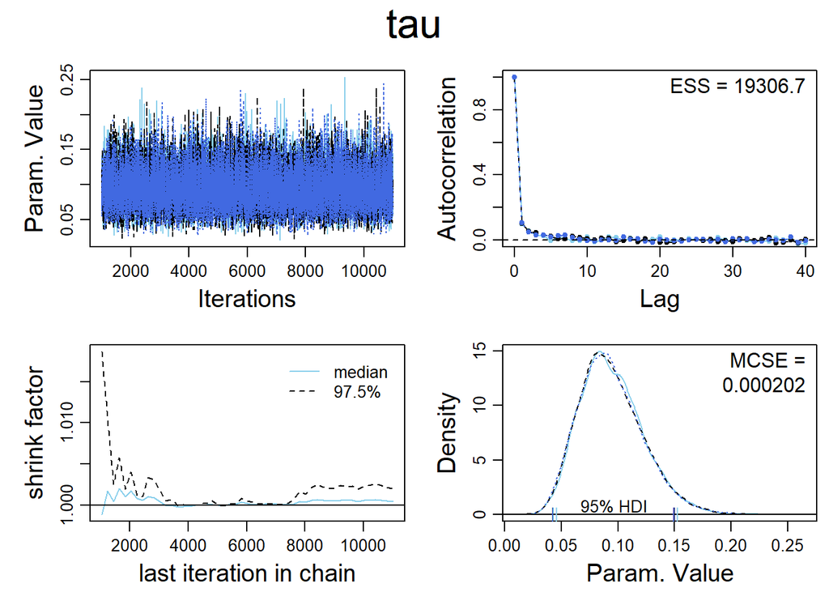

```r
# Diagnostics and Posteriors ----------------------------------------

# Tau
varName = paste0(parameters[1])
diagMCMC( codaObject=codaSamples , parName=varName );
saveGraph( file=paste0(fileNameRoot,varName) , type="png" )
```

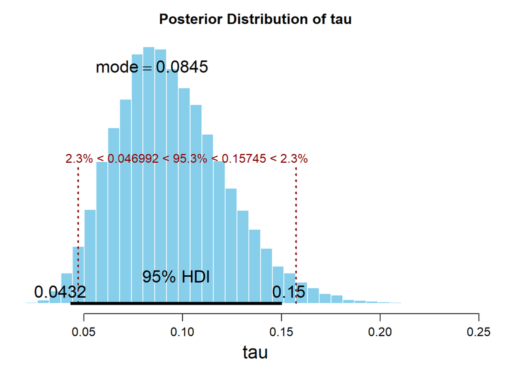

```
##          ESS       mean     median       mode hdiMass     hdiLow   hdiHigh
## tau 18958.34 0.09421204 0.09126512 0.08445561    0.95 0.04324165 0.1503386
##     compVal pGtCompVal  ROPElow ROPEhigh    pLtROPE   pInROPE    pGtROPE
## tau      NA         NA 0.046992  0.15745 0.02336667 0.9532667 0.02336667
```

```r
openGraph(); par( mar=c(3.5,0.5,2.5,0.5) , mgp=c(2.25,0.7,0) )
plotPost( codaSamples[,varName] , main=paste0('Posterior Distribution of ', varName) , xlab=paste0(varName), ROPE = c(0.046992, 0.15745)) # from summary(codaSamples)
```

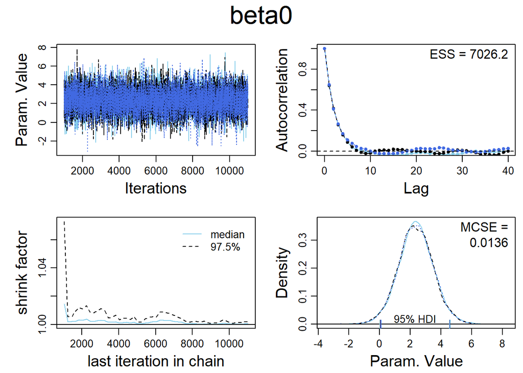

```r
# Beta 0
varName = paste0(parameters[2])
diagMCMC( codaObject=codaSamples , parName=varName );
saveGraph( file=paste0(fileNameRoot,varName) , type="png" )
```

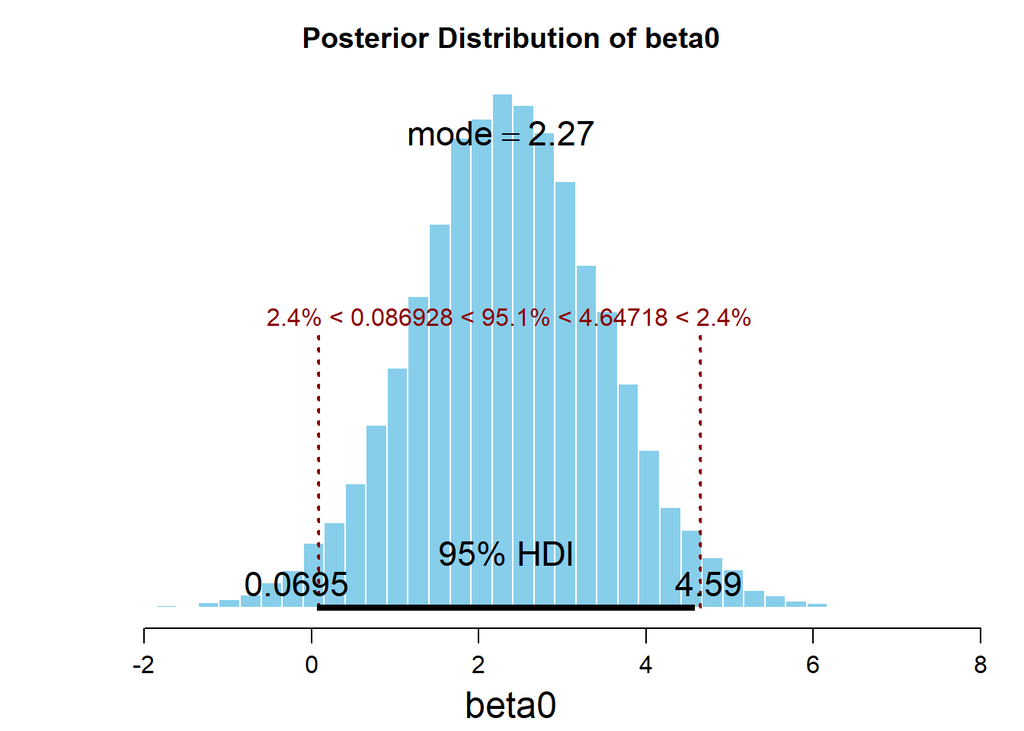

```
##            ESS     mean   median     mode hdiMass     hdiLow  hdiHigh compVal
## beta0 6535.775 2.360032 2.356137 2.267517    0.95 0.06953607 4.588574      NA
##       pGtCompVal  ROPElow ROPEhigh    pLtROPE pInROPE    pGtROPE
## beta0         NA 0.086928  4.64718 0.02446667  0.9514 0.02413333
```

```r
openGraph(); par( mar=c(3.5,0.5,2.5,0.5) , mgp=c(2.25,0.7,0) )
plotPost( codaSamples[,varName] , main=paste0('Posterior Distribution of ', varName) , xlab=paste0(varName), ROPE = c(0.086928 , 4.64718)) # from summary(codaSamples)
```

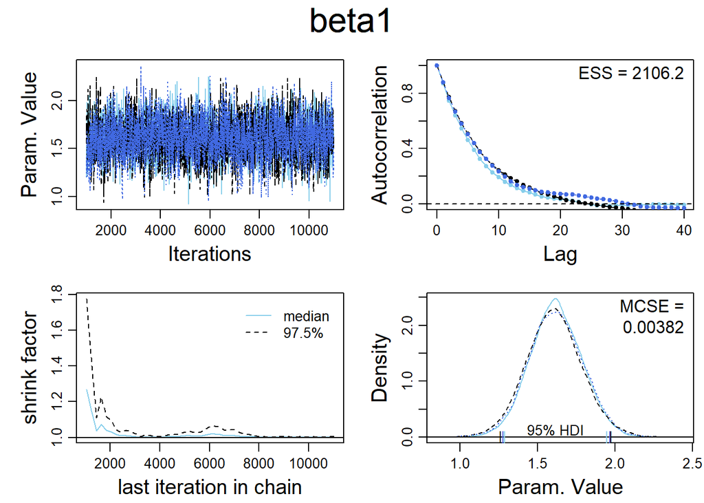

```r
# Beta 1
varName = paste0(parameters[3])
diagMCMC( codaObject=codaSamples , parName=varName );
saveGraph( file=paste0(fileNameRoot,varName) , type="png" )
```

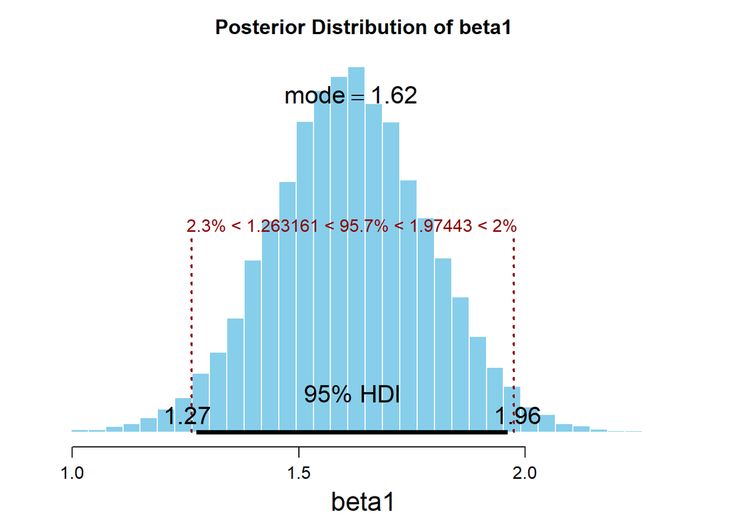

```
##           ESS     mean   median     mode hdiMass   hdiLow  hdiHigh compVal
## beta1 2232.45 1.613291 1.611752 1.615748    0.95 1.274216 1.962254      NA
##       pGtCompVal  ROPElow ROPEhigh pLtROPE   pInROPE    pGtROPE
## beta1         NA 1.263161  1.97443  0.0228 0.9569333 0.02026667
```

```r
openGraph(); par( mar=c(3.5,0.5,2.5,0.5) , mgp=c(2.25,0.7,0) )
plotPost( codaSamples[,varName] , main=paste0('Posterior Distribution of ', varName) , xlab=paste0(varName), ROPE = c(1.263161 , 1.97443)) # from summary(codaSamples)
```

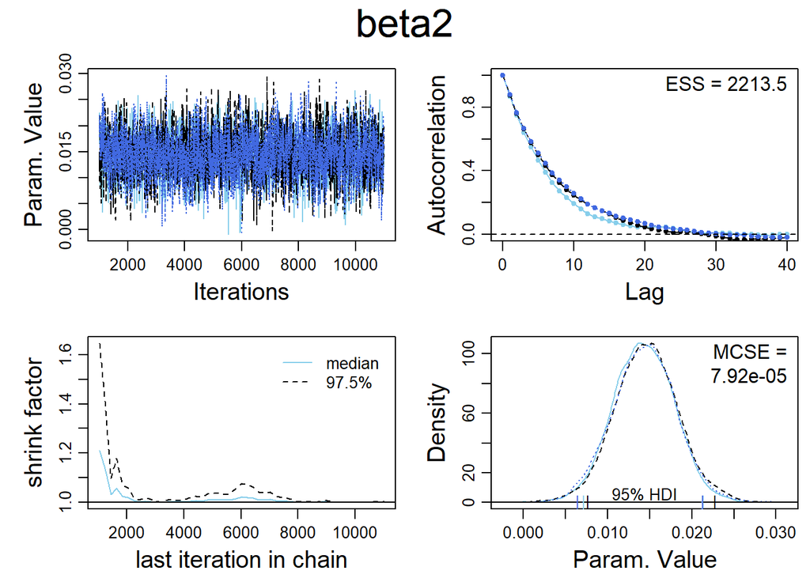

```r
# Beta 2
varName = paste0(parameters[4])
diagMCMC( codaObject=codaSamples , parName=varName );
saveGraph( file=paste0(fileNameRoot,varName) , type="png" )
```

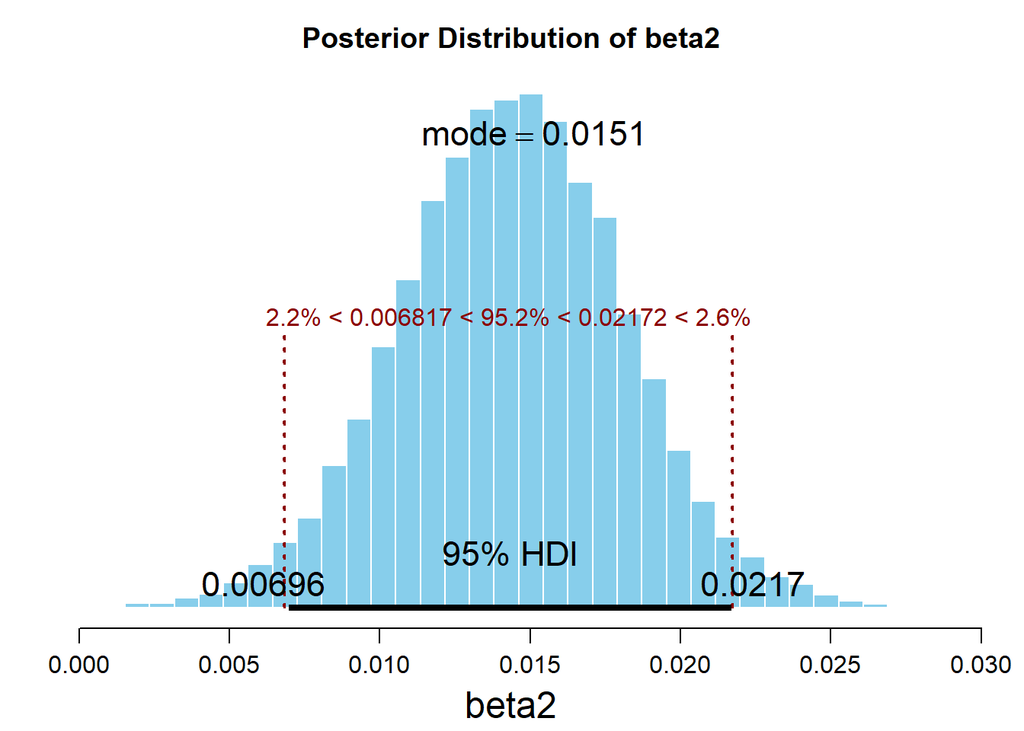

```
##            ESS       mean     median       mode hdiMass      hdiLow    hdiHigh
## beta2 2150.123 0.01441204 0.01442469 0.01513142    0.95 0.006963909 0.02169674
##       compVal pGtCompVal  ROPElow ROPEhigh    pLtROPE   pInROPE pGtROPE
## beta2      NA         NA 0.006817  0.02172 0.02243333 0.9517667  0.0258
```

```r
openGraph(); par( mar=c(3.5,0.5,2.5,0.5) , mgp=c(2.25,0.7,0) )
plotPost( codaSamples[,varName] , main=paste0('Posterior Distribution of ', varName) , xlab=paste0(varName), ROPE = c(0.006817 , 0.02172)) # from summary(codaSamples)
```

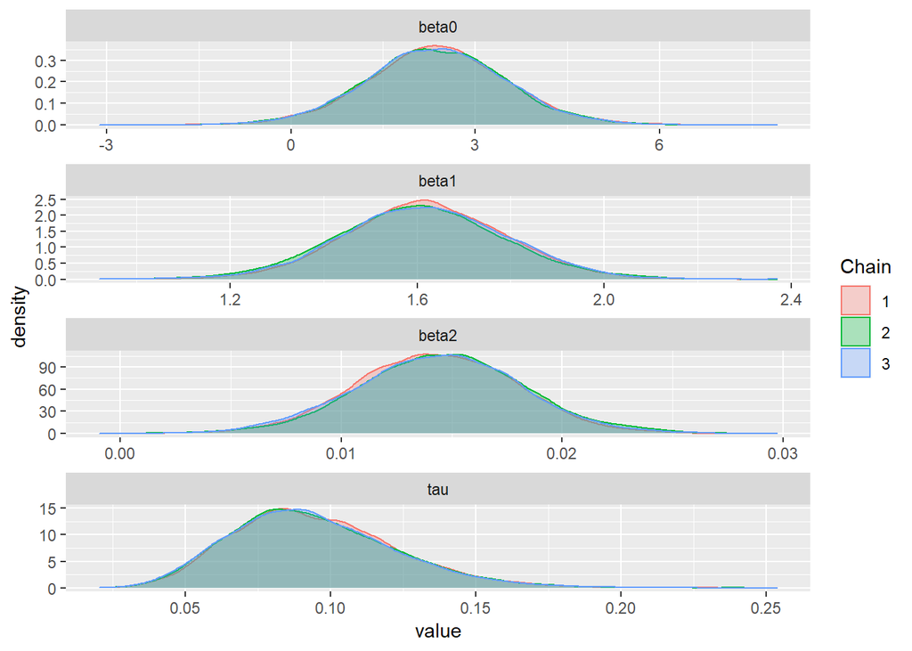

```r
# graphics.off()

# Density Plots
library(ggmcmc)
s = ggs(codaSamples)
d = ggs_density(s)
print(d)
```

```r
# Using classical methods (point estimates)
est.softDrink <- glm(time ~ distance + cases, data = dataList)
summary(est.softDrink)
```

```
##
## Call:
## glm(formula = time ~ distance + cases, data = dataList)
##
## Deviance Residuals:
##     Min       1Q   Median       3Q      Max
## -5.7880  -0.6629   0.4364   1.1566   7.4197
##
## Coefficients:
##             Estimate Std. Error t value Pr(>|t|)
## (Intercept) 2.341231   1.096730   2.135 0.044170 *
## distance    0.014385   0.003613   3.981 0.000631 ***
## cases       1.615907   0.170735   9.464 3.25e-09 ***
## ---
## Signif. codes:  0 '***' 0.001 '**' 0.01 '*' 0.05 '.' 0.1 ' ' 1
##
## (Dispersion parameter for gaussian family taken to be 10.62417)
##
##     Null deviance: 5784.54  on 24  degrees of freedom
## Residual deviance:  233.73  on 22  degrees of freedom
## AIC: 134.83
##
## Number of Fisher Scoring iterations: 2
```

```r
# Using Baysian Methods
summary(codaSamples)
```

```
##
## Iterations = 1001:11000
## Thinning interval = 1
## Number of chains = 3
## Sample size per chain = 10000
##
## 1. Empirical mean and standard deviation for each variable,
##    plus standard error of the mean:
##
##          Mean       SD  Naive SE Time-series SE
## beta0 2.36003 1.139478 6.579e-03      1.365e-02
## beta1 1.61329 0.175194 1.011e-03      3.825e-03
## beta2 0.01441 0.003726 2.151e-05      7.951e-05
## tau   0.09421 0.028122 1.624e-04      2.027e-04
##
## 2. Quantiles for each variable:
##
##          2.5%     25%     50%     75%   97.5%
## beta0 0.10240 1.62186 2.35614 3.10871 4.62531
## beta1 1.27112 1.49788 1.61175 1.72866 1.96024
## beta2 0.00702 0.01194 0.01442 0.01691 0.02178
## tau   0.04741 0.07424 0.09127 0.11164 0.15633
```